# 第6回 分類の判定を、混同行列で評価する（1行ずつ読む版）

## 前回からの接続

第5回は、肉に当てた光のスペクトルから、脂肪の割合を当てる式を作りました。当てたいものは、脂肪の割合のような「量」でした。

今日は、当てたいものが「迷惑メッセージか、そうでないか」の2択です。2択を当てることを、分類（classification）と呼びます。分類では、当たったか外れたかを、どう評価すればよいでしょうか。

## 今日の分析目標

本文から、迷惑メッセージをどう見分け、その見分け方をどう評価するかに答える。

携帯電話に届いたSMSの本文から、迷惑メッセージかどうかを判定します。まず、簡単なルールで判定し、正解率で評価します。ところが、正解率だけでは、良いフィルターかどうかが分かりません。そこで、当たりと外れを4つのマスに分けて数え（混同行列）、見逃しと誤検出を分けて評価します。最後に、手がかりをまとめて迷惑である確率を出し（ロジスティック回帰）、どこで切るかを動かします。

もう1つのねらいは、条件で処理を分ける書き方（if）を使い、ルールや判定のコードを読めるようになることです。「freeを含むなら迷惑」「数字が5字以上なら迷惑」を、ifで書きます。お手本ごとに、コードを1行ずつ読み（「1行ずつ読む」）、くり返しを少しだけ回して、変数の中身を見ます（「中身を見る」）。

### 公開データの世界

第5回は、食品の分析のデータで、数の列が100本並ぶ表でした。今日は、文章のデータです。数の表ではなく、人が書いたメッセージそのものです。データの形が変われば、道具の組み立て方も変わります。

### 場面

「当選しました。この番号に電話を」のような迷惑メッセージ（spam）が、携帯電話には毎日のように届きます。携帯電話の会社やアプリは、届く前に迷惑フォルダへ振り分けています。この仕組みを、迷惑メッセージのフィルターと呼びます。

届いたメッセージの本文から、迷惑か普通かを判定したい。答えは2つのうちのどちらかで、量ではなく2択を当てます（分類）。そして、作ったフィルターがどのくらい良いかも評価したい。

フィルターの誤りは2種類あります。迷惑メッセージを通してしまう誤り（見逃し）と、大事な連絡を迷惑フォルダに入れてしまう誤り（誤検出）です。どちらも困りますが、困り方は違います。

### 手元のデータ

SMS Spam Collectionは、研究のために集めた英語のSMS 5,574通のデータです。1行が1通です。

- `label`：迷惑（spam）か普通（ham）か
- `text`：本文

迷惑メッセージは、英国の利用者が迷惑SMSを投稿する掲示板などから集めたものです。普通のメッセージは、シンガポール国立大学の学生が、公開されることを承知して提供したものなどです。

データはUCI機械学習リポジトリで公開されていて（CC BY 4.0）、出典（Almeida, Gómez Hidalgo, Yamakami, 2011）を書けば使えます。

### 最後に出す答え

迷惑メッセージを、どれだけ捕まえ、普通のメッセージをどれだけ誤って捕まえるか。そして、そのフィルターを、どんな数で評価すればよいかです。

### 今日の一周（結果だけ先に）

コードの説明はあとにして、今日の解析を、結果だけで一度通して見ておきます。

1. ルールで見分ける：「freeを含むなら迷惑」と判定すると、正解率は0.894です。
2. 正解率を疑う：何も迷惑と言わないルールでも、正解率は0.874です。正解率だけでは分かりません。当たりと外れを4つのマスで数えると、freeのルールは、迷惑653通のうち484通を見逃しています。
3. 2つの割合：本文の数字を数え、5字以上なら迷惑とすると、見逃し96通、誤検出39通まで減ります。
4. 確率を出す：数字と15語から、ロジスティック回帰で迷惑である確率を出し、0.5で切ると、見逃し83通、誤検出23通です。数字のルールより、どちらも少なくなります。
5. しきい値：切る場所（しきい値）を動かすと、見逃しと誤検出が入れ替わります。全部のしきい値を1本の線（ROC曲線）にし、下の面積（AUC）で測ると0.981です。ところが、えっ、迷惑なのに、迷惑である確率が0.05より小さい通が24通あります。しきい値をどこに動かしても、捕まえられません。

このあと、この5つの段の中身を、1つずつ開けていきます。

### 今日の問いとやること

| 段 | 問い | やること |
| --- | --- | --- |
| ルールで見分ける（1・2節） | ルールで見分けられる？ | 「freeを含むなら迷惑」をifで書き、正解率を測る |
| 正解率を疑う（3節） | 正解率は信じてよい？ | 何も迷惑と言わないルールと比べ、4つのマスを数える |
| 2つの割合（4節） | 見逃しと誤検出は？ | 再現率と適合率を出し、数字を数えるルールと比べる |
| 確率を出す（5節） | 手がかりをまとめると？ | 数字と15語でロジスティック回帰の確率を出し、0.5で切る |
| しきい値（6節） | しきい値を動かすと？ | 切る場所を動かし、ROC曲線とAUCで測る。見逃した迷惑を読む |

### 今日の進め方

段ごとに、まずスライドで、その段の結論までを通して聞きます。段の終わりにノートへ移り、その段の節のセルを上から実行して、スライドと同じ数が出るかを確かめます。そして、段ごとに1つあるTODOに答えます。

TODOは、実行の前に結果を予想して書き、1か所を替えて実行し、予想と比べる形です。予想が外れても、かまいません。

正解率・混同行列・交差検証（cross-validation）などの計算には、`sklearn`の道具を使います。道具ごとに、中で何をしているかを、小さな例で確かめてから使います。

## 学習ゴール

この回を終えると、次のことができるようになります。

- 「語を含むなら迷惑」のような判定のルールを、ifを使った関数で書ける
- 少ない側を見つけたいとき、正解率だけでは評価できない理由を、何も見分けないルールと比べて説明できる
- 混同行列の4つのマス（当たり2つ・見逃し・誤検出）を読み、再現率と適合率を出せる
- ロジスティック回帰で迷惑である確率を出し、しきい値で切って判定できる
- しきい値を動かすと、見逃しと誤検出が入れ替わることを、表とROC曲線で確かめ、AUCで測れる

## 0. 準備

### 最初に実行する：道具を呼び出す

- 役割：このノートで使う道具（ライブラリ）を呼び出す
- 入力：なし
- 出力：なし（終わるとセルの左に ✓ が付く）

```python
import numpy as np
import pandas as pd
import matplotlib.pyplot as plt
```

### 図の日本語を表示できるようにする

- 役割：図の中の日本語が □ にならないようにし、図の大きさと字の大きさをそろえる
- 入力：なし
- 出力：「セットアップ完了」の表示

`try:`から先は、日本語表示の道具が動かなくなったときの保険で、中身は読まなくてかまいません。

```python
# 日本語が図の中で □ になるのを防ぐ
!pip install -q japanize-matplotlib
try:
    import japanize_matplotlib
# japanize が動かなくなったときの保険：同梱フォントを直接登録する
except Exception:
    from importlib.util import find_spec
    from matplotlib import font_manager as fm
    from pathlib import Path
    spec = find_spec('japanize_matplotlib')
    ttf = None
    if spec:
        ttf = next(Path(spec.origin).parent.rglob('*.ttf'), None)
    if ttf:
        fm.fontManager.addfont(str(ttf))
        name = fm.FontProperties(fname=str(ttf)).get_name()
        plt.rcParams['font.family'] = name

plt.rcParams['figure.figsize'] = (9, 5)
plt.rcParams['font.size'] = 13
plt.rcParams['axes.unicode_minus'] = False  # マイナス記号の化けを防ぐ
pd.set_option('display.max_colwidth', 80)
print('セットアップ完了')
```

```
セットアップ完了
```

### お手本：表を読み込む

- 役割：メッセージの表を読み込み、通数を数えて、先頭5行を見る
- 入力：データの置き場所`DATA_DIR`と、ファイル名`sms_spam.csv`
- 出力：表`raw`（5,574通）

```python
# データはこのリポジトリから読み込む
DATA_DIR = ('https://raw.githubusercontent.com/k0heiun0/'
            'applied_exercise_preview/main/shared/data')
raw = pd.read_csv(f'{DATA_DIR}/sms_spam.csv')
print(len(raw), '通')
raw.head()
```

```
5574 通
```

|  | label | text |
| --- | --- | --- |
| 0 | ham | Go until jurong point, crazy.. Available only in bugis n great world la e bu... |
| 1 | ham | Ok lar... Joking wif u oni... |
| 2 | spam | Free entry in 2 a wkly comp to win FA Cup final tkts 21st May 2005. Text FA ... |
| 3 | ham | U dun say so early hor... U c already then say... |
| 4 | ham | Nah I don't think he goes to usf, he lives around here though |

1通の本文は、短い英語の文章です。略語や打ち間違いも多くあります。

### お手本：表を整える

- 役割：同じ本文を1通にまとめ、本文の列の名前を日本語にし、迷惑なら1・普通なら0の列「迷惑」を作る
- 入力：表`raw`
- 出力：表`df`と、通数・迷惑の通数

`drop_duplicates('text')`は、同じ本文の行を、1行だけ残して消します。`(df['label'] == 'spam')`は、迷惑ならTrue、普通ならFalseの列で、`astype(int)`で1と0に直します。

```python
df = raw.drop_duplicates('text').reset_index(drop=True)
df = df.rename(columns={'text': '本文'})
df['迷惑'] = (df['label'] == 'spam').astype(int)
print(len(raw), '通 →', len(df), '通')
print(df['迷惑'].sum(), '通が迷惑')
```

```
5574 通 → 5171 通
653 通が迷惑
```

#### 1行ずつ読む

- 1行目：`raw`から、同じ本文の行を1行だけ残して消す（`drop_duplicates`）
- 続けて`reset_index(drop=True)`で、行の番号を0から振り直し、`df`にしまう
- 番号を振り直すと、行の番号が0から抜けなく並ぶ
- 2行目：列の名前textを、本文に替える（`rename`）
- 3行目：labelがspamならTrue、違えばFalse。`astype(int)`で1と0に直し、列「迷惑」にしまう
- 4行目：`len(表)`は行の数。整える前と後の通数を並べて出す
- 5行目：1と0の列の合計は、1の数。つまり迷惑の通数

#### 中身を見る：列「迷惑」

```python
df[['label', '迷惑']].head(3)
```

|  | label | 迷惑 |
| --- | --- | --- |
| 0 | ham | 0 |
| 1 | ham | 0 |
| 2 | spam | 1 |

spamの行だけが1、hamの行は0になった

同じ本文が何度も届いた分を1通にまとめ、5,171通にしました。列「迷惑」は、迷惑なら1、普通なら0で、これが答えの列になります。

## 1. どんなメッセージが届く？

ここから、段1「ルールで見分ける」（1・2節）です。問いは、簡単なルールで、迷惑メッセージを見分けられるか、です。

まず、迷惑がどのくらいの割合で届いているかを見ます。

### お手本：迷惑の割合

- 役割：迷惑（1）と普通（0）の通数と、迷惑の割合を出す
- 入力：表`df`の列「迷惑」
- 出力：通数と割合

1と0の列の平均は、1の割合になります。

```python
print(df['迷惑'].value_counts())
print(round(df['迷惑'].mean(), 3))
```

```
迷惑
0    4518
1     653
Name: count, dtype: int64
0.126
```

#### 1行ずつ読む

- 1行目：`value_counts()`は、値ごとに行の数を数える。0（普通）と1（迷惑）の通数
- 2行目：`mean()`は平均。1と0の列の平均は、1の割合
- `round(…, 3)`で、小数第3位までに丸める

5,171通のうち、迷惑は653通、普通は4,518通です。迷惑の割合は0.126で、8通に1通ほどです。少ない側を見つけたい、というこの偏りが、今日の話の鍵になります。

### お手本：迷惑の本文を読む

- 役割：迷惑の行だけを取り出し、本文の先頭5通を見る
- 入力：表`df`
- 出力：迷惑メッセージの本文5通

```python
df[df['迷惑'] == 1]['本文'].head()
```

```
2     Free entry in 2 a wkly comp to win FA Cup final tkts 21st May 2005. Text FA ...
5     FreeMsg Hey there darling it's been 3 week's now and no word back! I'd like ...
8     WINNER!! As a valued network customer you have been selected to receivea £90...
9     Had your mobile 11 months or more? U R entitled to Update to the latest colo...
11    SIX chances to win CASH! From 100 to 20,000 pounds txt> CSH11 and send to 87...
Name: 本文, dtype: object
```

#### 1行ずつ読む

- `df['迷惑'] == 1`：迷惑ならTrue、普通ならFalseの列
- `df[Trueの列]`：Trueの行だけを取り出した表
- `['本文']`で本文の列を取り出し、`head()`で先頭の5通を見る

free（無料）、win（当選）、claim（受け取る）、call（電話を）のような決まり文句があり、電話番号や短い番号が並びます。この特徴を、ルールにできないでしょうか。

## 2. ルールで見分けられる？

迷惑の本文には、freeがよく出てきます。そこで、本文にfreeを含むなら迷惑、含まないなら普通、と判定してみます。条件によって、答えを分けたいのです。

### 道具：文字列の中に語があるか

`語 in 文字列`は、文字列の中にその語があればTrue、なければFalseになります。`lower()`は、大文字を小文字にそろえます。FREEもFreeも、freeとして探せます。

```python
print('free' in 'Are you free now?')   # True
print('free' in 'Tired.')              # False
print('FREE entry'.lower())            # free entry
```

```
True
False
free entry
```

### 新しい書き方：if

条件によって、動かす行を分けるときは、`if`を使います。

- `if 条件:`の下の字下げした行は、条件がTrueのときだけ動く
- `else:`の下の行は、条件がFalseのときだけ動く

下の例では、`x`が5以上なので、上の`print`だけが動きます。`x = 7`を`x = 3`に替えると、下の`print`が動きます。

```python
x = 7
if x >= 5:
    print('5以上')     # 条件がTrueのときだけ動く
else:
    print('5未満')     # 条件がFalseのときだけ動く
```

```
5以上
```

### お手本：ルールの関数

- 役割：本文`text`に語`word`を含めば1（迷惑と判定）、含まなければ0（普通と判定）を返す
- 入力：本文`text`、探す語`word`
- 出力：1か0

```python
def rule(text, word):
    if word in text.lower():
        return 1          # 迷惑と判定
    else:
        return 0          # 普通と判定

print(rule('FREE entry into our weekly comp', 'free'))
print(rule('Tired. I have not slept well', 'free'))
```

```
1
0
```

#### 1行ずつ読む

- 1行目：関数`rule`を作る。入力は本文`text`と、探す語`word`の2つ
- `def`の下の字下げした行が、関数の中身。呼び出したときに動く
- 2行目：本文を小文字にそろえ（`text.lower()`）、その中に`word`があるかを調べる
- あればTrue、なければFalse。これが`if`の条件
- 3行目：条件がTrueのとき、1を返す（迷惑と判定）
- 4・5行目：条件がFalseのとき、0を返す（普通と判定）
- `return`は、関数の答えを返して、関数を終える
- 7行目：FREEを含む本文で呼ぶ。小文字にするとfreeを含むので1
- 8行目：freeを含まない本文で呼ぶ。0

#### 中身を見る：条件の中身

```python
text = 'Call FREEPHONE 0800 542 0578 now!'
print(text.lower())
print('free' in text.lower())
print(rule(text, 'free'))
```

```
call freephone 0800 542 0578 now!
True
1
```

小文字にすると、freephoneの中にfreeが入っている。だからTrueで、1

1通めはFREEを含むので1、2通めは含まないので0になりました。

### ifの分かれ道

下の図は、実際のメッセージ3通が、ifの分かれ道でどちらへ進むかを描いたものです。1通ずつ、条件で道が分かれます。「Are you free now?」のような普通のメッセージも、freeを含むので、迷惑の道へ進みます。

```
True  → return 1（迷惑と判定） FREE entry into our £250 weekly comp ...
True  → return 1（迷惑と判定） Are you free now?can i call now?
False → return 0（普通と判定） Tired. I haven't slept well the past few nights.
```

### お手本：全部の通に判定を付ける

- 役割：1通ずつ`rule`で判定し、リストにためて、列「判定」にする
- 入力：表`df`の本文
- 出力：迷惑と判定した通数

くり返しの結果をリストにためるのは、第4回と同じ書き方です。

```python
pred = []
for text in df['本文']:
    pred.append(rule(text, 'free'))
df['判定'] = pred
print(df['判定'].sum(), '通を迷惑と判定')
```

```
231 通を迷惑と判定
```

#### 1行ずつ読む

- 1行目：空のリスト`pred`を作る。ここに判定をためていく
- 2行目：列「本文」から1通ずつ取り出して`text`に入れ、字下げした行をくり返す
- 3行目：その1通を`rule`で判定し（1か0）、`pred`の後ろに足す（`append`）
- 5,171回くり返すと、`pred`には5,171個の1と0が並ぶ
- 4行目：リスト`pred`を、表の列「判定」にする
- 5行目：1と0の列の合計は、迷惑と判定した通数

#### 中身を見る：3通だけ回す

```python
pred = []
for text in df['本文'].head(3):
    pred.append(rule(text, 'free'))
    print(pred)
```

```
[0]
[0, 0]
[0, 0, 1]
```

1回ごとに、後ろに1つ足される。3通めはFreeで始まるので1

### お手本：正解率

- 役割：判定が当たった通の割合（正解率）を出す
- 入力：列「迷惑」（本当の答え）と列「判定」
- 出力：正解率

$$\text{正解率} = \frac{\text{判定が当たった通数}}{\text{全部の通数}}$$

`sklearn`の`accuracy_score(本当, 判定)`は、正解率を返す道具です。

```python
from sklearn.metrics import accuracy_score
print(round(accuracy_score(df['迷惑'], df['判定']), 3))
```

```
0.894
```

#### 1行ずつ読む

- 1行目：`sklearn`の評価の道具の中から、`accuracy_score`を呼び出す
- 2行目：本当の答え（列「迷惑」）と判定（列「判定」）を渡すと、正解率が返る
- `round(…, 3)`で、小数第3位までに丸めて表示する

#### accuracy_scoreがしていること

1通ずつ、本当の答えと判定を見比べ、同じなら当たりとします。当たりの通数を、全部の通数で割ります。たとえば、表の5通（行の番号0・1・2・8・75）なら、次のようになります。

| 行 | 本当 | 判定 | 当たり？ |
| --- | --- | --- | --- |
| 0 | 0 | 0 | ○ |
| 1 | 0 | 0 | ○ |
| 2 | 1 | 1 | ○ |
| 8 | 1 | 0 | × |
| 75 | 0 | 1 | × |

5通のうち当たりは3通で、正解率は3 ÷ 5 = 0.6です。これを5,171通で行ったのが、上の数です。

```python
df.loc[[0, 1, 2, 8, 75], ['迷惑', '判定']]
```

|  | 迷惑 | 判定 |
| --- | --- | --- |
| 0 | 0 | 0 |
| 1 | 0 | 0 |
| 2 | 1 | 1 |
| 8 | 1 | 0 |
| 75 | 0 | 1 |

#### 中身を見る：5通で正解率

```python
y = [0, 0, 1, 1, 0]      # 本当（行0・1・2・8・75）
p = [0, 0, 1, 0, 1]      # 判定
print(accuracy_score(y, p))
```

```
0.6
```

上の表の5通の本当と判定を、リストで渡した。5通のうち3通が当たりで、0.6

「freeを含むなら迷惑」だけで、正解率は0.894です。1行のルールで、9割ほどのメッセージを正しく判定できました。これは、良いフィルターと言えるでしょうか。

> 今日の重要概念（Python）：if

> ifは、条件が成り立つ（True）ときだけ、字下げしたブロックを実行する。elseの下は、成り立たないときに動く。

### TODO①：探す語を替える（予想 → 実行 → 比べる）

下のセルは、語`word`を含むなら迷惑と判定し、迷惑と判定した通数と正解率を表示します。2節のお手本と同じ4行で、語を変数`word`にしまったので、替えるのは2行目だけです。

まず、予想を書いてください。探す語を’xyz’（どのメッセージにも出てこない語）にすると、迷惑と判定する通数と正解率は、いくつになるでしょうか。

（ここに予想を書く）

予想を書いたら、セルの`'free'`を`'xyz'`に替えて実行してください。

```python
# TODO: 'free' を 'xyz' に替えて実行する
word = 'free'
pred_x = []
for text in df['本文']:
    pred_x.append(rule(text, word))
df['判定_x'] = pred_x
print(df['判定_x'].sum())   # 迷惑と判定した通数
print(round(accuracy_score(df['迷惑'], df['判定_x']), 3))   # 正解率
```

```
231
0.894
```

### やってみよう：予想と比べる

実行した結果を、予想と比べてください。何も迷惑と判定しないルールの正解率を見て、気づいたことを書いてください。

（ここに答えを書く）

’xyz’を含むメッセージは0通なので、全部を「普通」と判定します。それでも、正解率は0.874です。freeのルール（0.894）と、ほとんど変わりません。

### ここまでで分かったこと

| 段 | 分かったこと |
| --- | --- |
| ルールで見分ける（1・2節） | 「freeを含むなら迷惑」のルールで、正解率0.894 |
| 正解率を疑う（3節） | ？（このあとの段で） |
| 2つの割合（4節） | ？（このあとの段で） |
| 確率を出す（5節） | ？（このあとの段で） |
| しきい値（6節） | ？（このあとの段で） |

まだ分からないのは、正解率0.894が、本当に良い数なのか、です。

## 3. 正解率は信じてよい？

ここから、段2「正解率を疑う」（3節）です。問いは、正解率0.894を信じてよいか、です。

freeのルールは正解率0.894でしたが、何も迷惑と言わないルールでも0.874でした。差はわずかです。freeのルールは、何を当てて、何を外しているのでしょうか。

### なぜ87%も当たる？

迷惑は8通に1通（0.126）で、普通は0.874です。全部を「普通」と答えると、普通の4,518通がすべて当たります。正解率は、多い側（普通）の当たりで、ほとんど決まってしまいます。

正解率は、どこで当てて、どこで外したかを1つの数にまとめます。迷惑を1通も捕まえないフィルターでも、87%になります。当たりと外れを、種類に分けて数えたいのです。

### 本当と判定で、4つのマス

本当の答え（迷惑・普通）と、判定（迷惑・普通）の組で、メッセージを4つに分けます。

|  | 判定：普通 | 判定：迷惑 |
| --- | --- | --- |
| 本当：普通 | 普通を当てた（TN） | 誤検出（FP） |
| 本当：迷惑 | 見逃し（FN） | 迷惑を当てた（TP） |

普通（0）を先に、迷惑（1）を後に並べます。このあと使う`sklearn`の道具と同じ並びです。

4つのマスに通数を数えた表を、混同行列（confusion matrix）と呼びます。見逃しは、迷惑を普通と判定する誤りで、偽陰性（false negative、FN）とも呼びます。誤検出は、普通を迷惑と判定する誤りで、偽陽性（false positive、FP）とも呼びます。迷惑を当てたマスは真陽性（TP）、普通を当てたマスは真陰性（TN）です。

### お手本：混同行列を数える

- 役割：本当の答えと判定から、4つのマスの通数を数える
- 入力：列「迷惑」（本当の答え）と列「判定」
- 出力：2×2の表

`sklearn`の`confusion_matrix(本当, 判定)`は、4つのマスの通数を2×2の表で返す道具です。

```python
from sklearn.metrics import confusion_matrix
print(confusion_matrix(df['迷惑'], df['判定']))
```

```
[[4456   62]
 [ 484  169]]
```

#### 1行ずつ読む

- 1行目：`sklearn`の評価の道具の中から、`confusion_matrix`を呼び出す
- 2行目：本当の答えと判定を渡すと、2×2の表が返る。それを表示する
- 渡す順は、本当が先、判定が後

#### confusion_matrixがしていること

1通ずつ、本当の答え（行）と判定（列）の組を見て、当てはまるマスに1を足します。正解率のときと同じ5通なら、次のようになります。

| 行 | 本当 | 判定 | マス |
| --- | --- | --- | --- |
| 0 | 0 | 0 | TN |
| 1 | 0 | 0 | TN |
| 2 | 1 | 1 | TP |
| 8 | 1 | 0 | FN |
| 75 | 0 | 1 | FP |

この5通なら、TNが2、TP・FN・FPが1ずつです。これを5,171通で数えたのが、上の4つの数です。

並びは、上の行が本当の普通、下の行が本当の迷惑、左の列が判定の普通、右の列が判定の迷惑です。`sklearn`は0、1の順に並べます。教科書やネットの記事には、迷惑（1）を左上に置く表もあるので、表を読むときは、行と列の名前を先に確かめます。

#### 中身を見る：5通の混同行列

```python
y = [0, 0, 1, 1, 0]      # 本当（行0・1・2・8・75）
p = [0, 0, 1, 0, 1]      # 判定
print(confusion_matrix(y, p))
```

```
[[2 1]
 [1 1]]
```

上の表と同じ5通。TNが2、FP・FN・TPが1ずつ。上の行が本当の0（普通）、左の列が判定の0（普通）

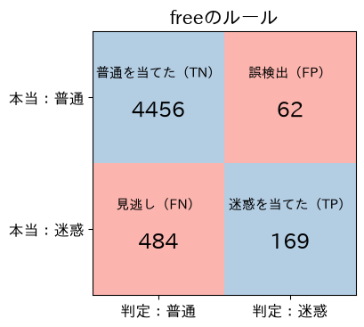

迷惑653通のうち、freeのルールで捕まえたのは169通です。484通を見逃しています。普通4,518通のうち、62通を誤って迷惑と判定しました。

正解率は、当たりの2つのマス（169と4,456）を全体で割ったものです。当たりのほとんどは、普通を普通と言った4,456通です。何も迷惑と言わないルールなら、迷惑653通をすべて見逃しますが、それでも正解率は0.874になります。

> 今日の重要概念（統計）：混同行列

> 正解率だけで見ない。混同行列の4つのマスを数え、見逃しと誤検出を分けて評価する。

### TODO②：探す語をprizeに（予想 → 実行 → 比べる）

下のセルは、語`word`を含むなら迷惑と判定し、混同行列を表示します。prizeは「賞品」で、普通のメッセージにはめったに出ない語です。

まず、予想を書いてください。探す語をprizeにすると、見逃しと誤検出は、freeと比べてどう変わるでしょうか。

（ここに予想を書く）

予想を書いたら、セルの`'free'`を`'prize'`に替えて実行してください。

```python
# TODO: 'free' を 'prize' に替えて実行する
word = 'free'
pred_x = []
for text in df['本文']:
    pred_x.append(rule(text, word))
df['判定_x'] = pred_x
print(confusion_matrix(df['迷惑'], df['判定_x']))
```

```
[[4456   62]
 [ 484  169]]
```

### やってみよう：予想と比べる

実行した結果を、予想と比べてください。見逃しと誤検出は、それぞれどう変わりましたか。

（ここに答えを書く）

prizeでは、誤検出は0通です。でも、見逃しは576通に増えました。prizeは迷惑にしか出てこないので、迷惑と言えば必ず当たります。でも、prizeを含む迷惑は少ないので、ほとんどを見逃します。freeとprizeのどちらが良いかは、2つの誤りをどう比べるかで決まります。

### ここまでで分かったこと

| 段 | 分かったこと |
| --- | --- |
| ルールで見分ける（1・2節） | 「freeを含むなら迷惑」のルールで、正解率0.894 |
| 正解率を疑う（3節） | 何も迷惑と言わなくても0.874。4つのマスで数える |
| 2つの割合（4節） | ？（このあとの段で） |
| 確率を出す（5節） | ？（このあとの段で） |
| しきい値（6節） | ？（このあとの段で） |

まだ分からないのは、見逃しと誤検出を、どんな数で比べればよいか、です。

## 4. 見逃しと誤検出は？

ここから、段3「2つの割合」（4節）です。問いは、見逃しと誤検出を、どんな数で比べればよいか、です。

混同行列で、見逃しと誤検出を分けて数えられました。でも、通数のままでは、迷惑の多いデータと少ないデータで比べにくいです。割合にして、2つの数で評価します。

### 再現率と適合率

再現率（recall）は、本当に迷惑の通のうち、迷惑と判定できた割合です。見逃しが少ないほど、1に近くなります。

$$\text{再現率} = \frac{TP}{TP + FN}$$

適合率（precision）は、迷惑と判定した通のうち、本当に迷惑だった割合です。誤検出が少ないほど、1に近くなります。

$$\text{適合率} = \frac{TP}{TP + FP}$$

### お手本：2つの割合

- 役割：本当の答えと判定から、再現率と適合率を出す
- 入力：列「迷惑」と列「判定」
- 出力：再現率と適合率（小数第3位まで）

`recall_score(本当, 判定)`は再現率、`precision_score(本当, 判定)`は適合率を返す道具です。

```python
from sklearn.metrics import recall_score, precision_score
print(round(recall_score(df['迷惑'], df['判定']), 3))      # 再現率
print(round(precision_score(df['迷惑'], df['判定']), 3))   # 適合率
```

```
0.259
0.732
```

#### 1行ずつ読む

- 1行目：再現率の道具`recall_score`と、適合率の道具`precision_score`を呼び出す
- 2行目：本当の答えと判定を渡し、再現率を出す
- 3行目：同じ2つを渡し、適合率を出す

#### 2つの道具がしていること

どちらも、混同行列の4つのマスのうち、2つだけを使います。

- `recall_score`：下の行（本当に迷惑）だけを見る。TP ÷ (TP + FN) = 169 ÷ (169 + 484)
- `precision_score`：右の列（迷惑と判定）だけを見る。TP ÷ (TP + FP) = 169 ÷ (169 + 62)

#### 中身を見る：5通の2つの割合

```python
y = [0, 0, 1, 1, 0]      # 本当（行0・1・2・8・75）
p = [0, 0, 1, 0, 1]      # 判定
print(recall_score(y, p), precision_score(y, p))
```

```
0.5 0.5
```

再現率：本当に迷惑の2通（行2・8）のうち、迷惑と判定したのは1通。適合率：迷惑と判定した2通（行2・75）のうち、本当に迷惑は1通

freeのルールは、再現率0.259で、迷惑の4通に1通しか捕まえていません。適合率は0.732で、迷惑と言った4通のうち3通ほどは本当に迷惑です。正解率0.894からは見えなかった弱さが、再現率に出ました。

### お手本：prizeのルールの2つの割合

- 役割：prizeを含むなら迷惑、のルールで判定し、再現率と適合率を出す
- 入力：表`df`
- 出力：再現率と適合率

```python
pred_p = []
for text in df['本文']:
    pred_p.append(rule(text, 'prize'))
df['判定_p'] = pred_p
print(round(recall_score(df['迷惑'], df['判定_p']), 3))
print(round(precision_score(df['迷惑'], df['判定_p']), 3))
```

```
0.118
1.0
```

#### 1行ずつ読む

- 1〜4行目：2節と同じ形。探す語をprizeにして、列「判定_p」を作る
- 5・6行目：再現率と適合率を出す

prizeは適合率1.0ですが、再現率は0.118です。1つの語では、迷惑の一部しか捕まえられません。

### 迷惑には、番号が並ぶ

迷惑の本文には、電話番号や、返信先の短い番号が書いてあります。普通のメッセージに、数字はあまり出てきません。本文の中の数字を数えたら、手がかりにならないでしょうか。

文字列も、`for ch in 文字列:`で1字ずつ取り出せます。`isdigit()`は、その字が数字ならTrueを返します。

```python
for ch in 'a1b2':
    print(ch, ch.isdigit())
```

```
a False
1 True
b False
2 True
```

### お手本：数字を数える関数

- 役割：本文を1字ずつ見て、数字の字数を数える
- 入力：本文`text`
- 出力：数字の字数

```python
def n_digits(text):
    n = 0
    for ch in text:          # 本文を1字ずつ
        if ch.isdigit():     # 数字なら
            n = n + 1        # 1を足す
    return n

print(n_digits('call 08707509020 now'))
```

```
11
```

#### 1行ずつ読む

- 1行目：関数`n_digits`を作る。入力は本文`text`
- 2行目：数えた数をためる変数`n`を、0から始める
- 3行目：本文を1字ずつ取り出して`ch`に入れる
- 4行目：`ch`が数字のときだけ、5行目へ進む
- 5行目：`n`に1を足して、`n`にしまい直す
- 6行目：全部の字を見終わったら`n`を返す。字下げが`for`の外なので、最後に1回だけ動く
- 8行目：電話番号の入った本文で試す

#### 中身を見る：1字ずつのnの変化

```python
n = 0
for ch in 'call 0870':
    if ch.isdigit():
        n = n + 1
    print(ch, n)
```

```
c 0
a 0
l 0
l 0
  0
0 1
8 2
7 3
0 4
```

数字の字のところでだけ、`n`が1つ増える

### お手本：数字の数の列

- 役割：全部の通で数字を数えて列「数字」にし、迷惑と普通で平均を比べる
- 入力：表`df`の本文
- 出力：迷惑（1）と普通（0）の、数字の字数の平均

```python
nd = []
for text in df['本文']:
    nd.append(n_digits(text))
df['数字'] = nd
print(df.groupby('迷惑')['数字'].mean().round(1))
```

```
迷惑
0     0.3
1    15.5
Name: 数字, dtype: float64
```

#### 1行ずつ読む

- 1〜4行目：2節の判定と同じ形。1通ずつ`n_digits`で数え、リストにためて列「数字」にする
- 5行目：`groupby('迷惑')`で迷惑（1）と普通（0）に分け、列「数字」の平均を出す
- `round(1)`で、小数第1位までに丸める

迷惑は平均15.5字、普通は平均0.3字です。

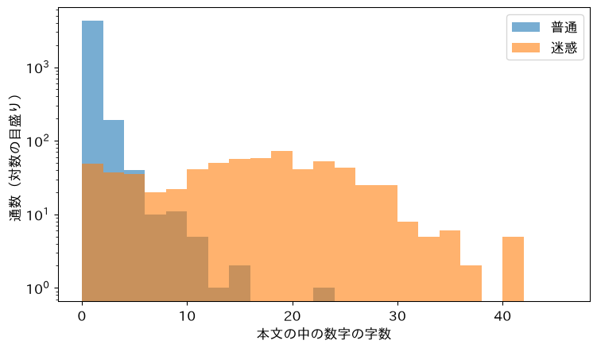

普通はほとんどが0字で、迷惑は数字が何字も並ぶ通が多くあります。数字の数で、ほぼ分かれます。

### お手本：数字のルール

- 役割：数字が5字以上なら迷惑と判定し、混同行列と2つの割合を出す
- 入力：表`df`の列「数字」
- 出力：混同行列と、再現率・適合率

```python
pred_d = []
for n in df['数字']:
    if n >= 5:
        pred_d.append(1)     # 5字以上なら迷惑
    else:
        pred_d.append(0)
df['判定_数字'] = pred_d
print(confusion_matrix(df['迷惑'], df['判定_数字']))
print(round(recall_score(df['迷惑'], df['判定_数字']), 3))
print(round(precision_score(df['迷惑'], df['判定_数字']), 3))
```

```
[[4479   39]
 [  96  557]]
0.853
0.935
```

#### 1行ずつ読む

- 2行目：列「数字」から、1通ずつ字数を取り出して`n`に入れる
- 3〜6行目：`n`が5以上なら1、そうでなければ0を、`pred_d`の後ろに足す
- `rule`と違い、ifを関数に入れず、くり返しの中に直接書いた
- 7行目：リストを列「判定_数字」にする
- 8行目：混同行列を表示する
- 9・10行目：再現率と適合率を表示する

見逃しは、freeのルールの484通から96通に減りました。誤検出は39通です。再現率0.853、適合率0.935で、freeのルールより、どちらも良くなりました。

> 重要：2つの誤りの重さは違う

> 見逃しは、迷惑が届いてしまう。誤検出は、大事な連絡が届かない。重さが違うので、2つを分けて見る。

### TODO③：数字のしきいを替える（予想 → 実行 → 比べる）

下のセルは、数字が`k`字以上なら迷惑と判定し、混同行列と2つの割合を表示します。

まず、予想を書いてください。数字が1字でもあれば迷惑、にすると、再現率と適合率はどうなるでしょうか。

（ここに予想を書く）

予想を書いたら、セルの`5`を`1`に替えて実行してください。

```python
# TODO: 5 を 1 に替えて実行する
k = 5
pred_x = []
for n in df['数字']:
    if n >= k:
        pred_x.append(1)
    else:
        pred_x.append(0)
df['判定_x'] = pred_x
print(confusion_matrix(df['迷惑'], df['判定_x']))
print(round(recall_score(df['迷惑'], df['判定_x']), 3))
print(round(precision_score(df['迷惑'], df['判定_x']), 3))
```

```
[[4479   39]
 [  96  557]]
0.853
0.935
```

### やってみよう：予想と比べる

実行した結果を、予想と比べてください。再現率と適合率は、それぞれどう変わりましたか。

（ここに答えを書く）

再現率は0.94に上がりました。でも、誤検出が715通に増え、適合率は0.462に下がりました。しきいを下げると、迷惑を広く捕まえますが、普通も巻き込みます。しきいを上げると、確かなものだけを捕まえ、見逃しが増えます。再現率と適合率の両方を、同時に1にするのは難しいのです。

### ここまでで分かったこと

| 段 | 分かったこと |
| --- | --- |
| ルールで見分ける（1・2節） | 「freeを含むなら迷惑」のルールで、正解率0.894 |
| 正解率を疑う（3節） | 何も迷惑と言わなくても0.874。4つのマスで数える |
| 2つの割合（4節） | 数字が5字以上なら迷惑：見逃し96・誤検出39 |
| 確率を出す（5節） | ？（このあとの段で） |
| しきい値（6節） | ？（このあとの段で） |

まだ分からないのは、数字と語を、まとめて使えないか、です。

## 5. 手がかりをまとめると？

ここから、段4「確率を出す」（5節）です。問いは、数字と語の手がかりを、まとめて1つの確率にできないか、です。

数字のルールは、見逃し96通・誤検出39通でした。迷惑の決まり文句（free、claim、prize…）も、手がかりになりました。手がかりを、迷惑である確率にまとめ、確率で判定します。

### お手本：1つの語の列を作る関数

- 役割：1通ずつ`rule`で判定し、全部の通の1/0のリストを返す
- 入力：探す語`word`
- 出力：全部の通の1/0のリスト

2節では、語ごとに、1通ずつ`rule`で判定してリストにためました。語を15個にするなら、同じ4行を15回書くことになります。そこで、1回分を関数にまとめ、語をくり返しの外から渡します。中身は2節の4行と同じです。

```python
def rule_col(word):
    pred = []
    for text in df['本文']:
        pred.append(rule(text, word))
    return pred
```

#### 1行ずつ読む

- 1行目：関数`rule_col`を作る。入力は探す語`word`
- 2〜4行目：2節の4行と同じ。`'free'`のところが`word`になった
- 5行目：ためたリスト`pred`を返す

### お手本：15語の列

- 役割：迷惑によく出てくる15語のそれぞれで、含めば1・なければ0の列を作り、数字の数と合わせて手がかりの列の名前`cols`にする
- 入力：語のリスト`words`
- 出力：手がかりの本数

**書き方メモ（読み飛ばしてよい）**

15語は、迷惑メッセージによく出てくる語を、こちらで選びました。本当は、語を選ぶのも、訓練の組だけを見て行うのが公平です。全部の通を見て選ぶと、テストの通の答えを少しのぞいたことになります（第2回のリーク）。

```python
words = ['free', 'txt', 'claim', 'prize', 'call', 'win', '£',
         'www', 'urgent', 'mobile', 'reply', 'stop', 'cash',
         'service', 'new']
for w in words:
    df[w] = rule_col(w)          # 語を含めば1、なければ0
cols = ['数字'] + words
print(len(words), '語と数字で', len(cols), '本の手がかり')
```

```
15 語と数字で 16 本の手がかり
```

#### 1行ずつ読む

- 1〜3行目：15個の語を並べたリストを`words`にしまう。長いので3行に折り返した
- 4行目：`words`から1語ずつ取り出して`w`に入れる
- 5行目：その語を含めば1・なければ0のリストを作り、語の名前の列にする
- 6行目：「数字」と15語をつないだリスト（`+`でつなぐ）。7行目：本数を表示

#### 中身を見る：語の列

```python
df[['free', 'txt', 'claim', 'call', '数字']].head(3)
```

|  | free | txt | claim | call | 数字 |
| --- | --- | --- | --- | --- | --- |
| 0 | 0 | 0 | 0 | 0 | 0 |
| 1 | 0 | 0 | 0 | 0 | 0 |
| 2 | 1 | 1 | 0 | 0 | 25 |

語の列は、その語を含めば1。3通めは、freeを含むので1

### 0と1を、確率で当てる

$x_{i1}, \dots, x_{i,16}$は、$i$番目の通の16本の手がかりです。まず、手がかりの1次式の値$z_i$を作り、それをシグモイドという関数で0〜1に収めます。$\hat{p}_i$が、迷惑である確率です。この式の作り方を、ロジスティック回帰（logistic regression）と呼びます。

$$z_i = b_0 + b_1 x_{i1} + \cdots + b_{16} x_{i,16}, \qquad
\hat{p}_i = \frac{1}{1 + e^{-z_i}}$$

シグモイドは、$z$が大きいほど1に、小さいほど0に近づき、$z = 0$でちょうど0.5になります。どんな$z$でも、0〜1の間に収まります。

式を作った通で確率を出すと、甘くなります（第2回の過学習）。そこで、第4回の交差検証と同じように、5つの組に分け、1つの組を残して式を作り、残した組の通の確率を出します。第4回は、この手順を自分で書きました。今日は、道具`cross_val_predict`で行います。

### お手本：交差検証で確率を出す

- 役割：交差検証で、全部の通の「迷惑である確率」を出す
- 入力：式の作り方`LogisticRegression()`、手がかりの列`df[cols]`、答えの列`df['迷惑']`
- 出力：全部の通の確率（列「確率」）

`cross_val_predict(式の作り方, 手がかり, 答え, cv=5)`は、交差検証で全部の通の予測を出す道具です。`cv=5`は、5つの組に分けるという意味です。`method='predict_proba'`を付けると、判定（0か1）ではなく、確率を返します。

```python
from sklearn.linear_model import LogisticRegression
from sklearn.model_selection import cross_val_predict
p = cross_val_predict(LogisticRegression(), df[cols], df['迷惑'],
                      cv=5, method='predict_proba')
df['確率'] = p[:, 1]
print(round(df['確率'].min(), 3), round(df['確率'].max(), 3))
```

```
0.005 1.0
```

#### 1行ずつ読む

- 1・2行目：ロジスティック回帰の道具と、交差検証の道具を呼び出す
- 3・4行目：式の作り方、16本の手がかりの列、答えの列を渡す。`cv=5`は5つの組。`method='predict_proba'`で、全部の通の確率が`p`に返る
- 1行に長いので、3行目の途中で折り返した（かっこの中なら折り返せる）
- 5行目：`p`の右の列（迷惑の確率）を取り出し、列「確率」にしまう
- 6行目：確率のいちばん小さい値と、いちばん大きい値を表示する

確率は0.005〜1.0です。0〜1をはみ出しません。

#### predict_probaがしていること

`p`には、1通に2つの確率が入っています。左の列（0番）が普通である確率、右の列（1番）が迷惑である確率で、2つを足すと1です。`p[:, 1]`は「すべての行の、1番の列」という意味で、迷惑の確率だけを取り出します。下のセルで、行0・1・2・8・75の5通を見てみます。

```python
print(p[[0, 1, 2, 8, 75]].round(3))
```

```
[[0.992 0.008]
 [0.992 0.008]
 [0.    1.   ]
 [0.    1.   ]
 [0.944 0.056]]
```

#### cross_val_predictがしていること

表を上から順に5つの組に分けます。1回目は、2〜5番目の組で式を作り、1番目の組の通の確率を出します。2回目は、2番目の組を残します。これを5回くり返すと、どの通も、自分を見ていない式から確率をもらいます。

| 回 | 1組 | 2組 | 3組 | 4組 | 5組 |
| --- | --- | --- | --- | --- | --- |
| 1回目 | 確率を出す | 式を作る | 式を作る | 式を作る | 式を作る |
| 2回目 | 式を作る | 確率を出す | 式を作る | 式を作る | 式を作る |
| … |  |  |  |  |  |
| 5回目 | 式を作る | 式を作る | 式を作る | 式を作る | 確率を出す |

#### 中身を見る：確率の列

```python
df[['迷惑', '確率']].head(3)
```

|  | 迷惑 | 確率 |
| --- | --- | --- |
| 0 | 0 | 0.008459 |
| 1 | 0 | 0.008459 |
| 2 | 1 | 1.000000 |

1通に1つずつ、確率が付いた。迷惑（1）の行ほど確率が高い

### お手本：確率を描く

- 役割：迷惑と普通で、確率の分かれ方を描き比べる
- 入力：列「確率」と列「迷惑」
- 出力：2色の柱の図

`plt.yscale('log')`は、縦軸を10倍ごとの目盛りにします。少ない迷惑も見えるようにするためです。

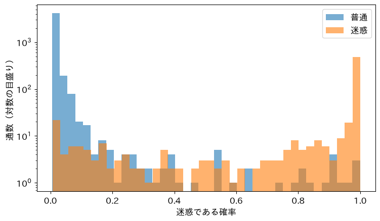

```python
ham = df[df['迷惑'] == 0]['確率']
spam = df[df['迷惑'] == 1]['確率']
plt.hist(ham, bins=40, alpha=0.6, label='普通')
plt.hist(spam, bins=40, alpha=0.6, label='迷惑')
plt.yscale('log')
plt.xlabel('迷惑である確率')
plt.ylabel('通数（対数の目盛り）')
plt.legend()
plt.show()
```

#### 1行ずつ読む

- 1行目：普通の行だけを取り出し、確率の列を`ham`にしまう
- 2行目：迷惑の行の確率を`spam`にしまう
- 3・4行目：確率を40の区間に分けて柱を描く（`hist`）
- `alpha=0.6`で半透明にし、重なりを見せる。`label`は凡例に出す名前
- 5行目：縦軸を10倍ごとの目盛りにする
- 6〜8行目：軸の名前と凡例を付ける。9行目：図を表示する

普通は0のまわり、迷惑は1のまわりに多くあります。迷惑ほど、確率が高くなりました。

### お手本：確率を切って判定する

- 役割：確率が0.5以上なら迷惑と判定し、混同行列と2つの割合を出す
- 入力：列「確率」
- 出力：混同行列と、再現率・適合率

`df['確率'] >= 0.5`は、0.5以上ならTrue、違えばFalseの列です。`astype(int)`で1と0に直します。0節で列「迷惑」を作ったのと同じ書き方です。

```python
df['判定_式'] = (df['確率'] >= 0.5).astype(int)
print(confusion_matrix(df['迷惑'], df['判定_式']))
print(round(recall_score(df['迷惑'], df['判定_式']), 3))
print(round(precision_score(df['迷惑'], df['判定_式']), 3))
```

```
[[4495   23]
 [  83  570]]
0.873
0.961
```

#### 1行ずつ読む

- 1行目：`df['確率'] >= 0.5`は、1通ずつ0.5と比べ、以上ならTrueの列。`astype(int)`で1と0に直し、列「判定_式」にしまう
- 2行目：混同行列を表示する
- 3・4行目：再現率と適合率を表示する

#### 中身を見る：確率と判定

```python
df[['確率', '判定_式']].head(3)
```

|  | 確率 | 判定_式 |
| --- | --- | --- |
| 0 | 0.008459 | 0 |
| 1 | 0.008459 | 0 |
| 2 | 1.000000 | 1 |

0.5以上の行だけが1になった

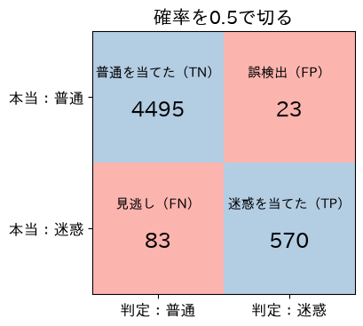

迷惑である確率が半分以上なら、迷惑と判定しました。見逃しは83通、誤検出は23通です。数字のルール（見逃し96・誤検出39）より、どちらも少なくなりました。16本の手がかりを、1つの確率にまとめた効果です。

> 重要：確率を切って判定する

> ロジスティック回帰は、手がかりの1次式をシグモイドで0〜1に収め、迷惑である確率を出す。確率をしきい値で切ると、判定になる。

### TODO④：手がかりから数字を外す（予想 → 実行 → 比べる）

下のセルは、手がかりの列`cols_x`で交差検証の確率を出し、0.5で切った混同行列を表示します。

まず、予想を書いてください。手がかりを15語だけにする（数字を外す）と、見逃しは83通から増えるでしょうか、減るでしょうか。

（ここに予想を書く）

予想を書いたら、セルの`['数字'] + words`を`words`に替えて実行してください。

```python
# TODO: ['数字'] + words を words に替えて実行する
cols_x = ['数字'] + words
p = cross_val_predict(LogisticRegression(), df[cols_x], df['迷惑'],
                      cv=5, method='predict_proba')
df['判定_x'] = (p[:, 1] >= 0.5).astype(int)
print(confusion_matrix(df['迷惑'], df['判定_x']))
```

```
[[4495   23]
 [  83  570]]
```

### やってみよう：予想と比べる

実行した結果を、予想と比べてください。数字を外すと、見逃しと誤検出はどう変わりましたか。

（ここに答えを書く）

15語だけでは、見逃しが175通に増えました。16本の手がかりの中で、数字の数がいちばん効く手がかりです。

### ここまでで分かったこと

| 段 | 分かったこと |
| --- | --- |
| ルールで見分ける（1・2節） | 「freeを含むなら迷惑」のルールで、正解率0.894 |
| 正解率を疑う（3節） | 何も迷惑と言わなくても0.874。4つのマスで数える |
| 2つの割合（4節） | 数字が5字以上なら迷惑：見逃し96・誤検出39 |
| 確率を出す（5節） | 数字と15語で確率。0.5で切ると見逃し83・誤検出23 |
| しきい値（6節） | ？（このあとの段で） |

まだ分からないのは、0.5で切ったのは正しかったのか、です。

## 6. しきい値を動かすと？

ここから、段5「しきい値」（6節）です。問いは、確率を切る場所を動かすと、見逃しと誤検出はどう変わるか、です。

0.5で切ると、見逃しは83通、誤検出は23通でした。見逃しをもっと減らしたいなら、0.5より下で切ればよいはずです。確率を切る場所を、しきい値（threshold）と呼びます。しきい値を下げると、迷惑をより多く捕まえます。

### お手本：しきい値ごとに数える

- 役割：しきい値を0.1〜0.9に動かし、見逃しと誤検出をリストにためて、表にする
- 入力：列「確率」
- 出力：しきい値ごとの見逃しと誤検出の表

`m = confusion_matrix(…)`の2×2の表から、1マスを`m[行, 列]`で取り出します（5節の`p[:, 1]`と同じ形です）。番号は0から数えます。見逃しは下の行・左の列なので`m[1, 0]`、誤検出は上の行・右の列なので`m[0, 1]`です。

```python
ts = [0.1, 0.2, 0.3, 0.4, 0.5, 0.6, 0.7, 0.8, 0.9]
fns = []
fps = []
for t in ts:
    pred = (df['確率'] >= t).astype(int)
    m = confusion_matrix(df['迷惑'], pred)
    fns.append(m[1, 0])          # 見逃し
    fps.append(m[0, 1])          # 誤検出
print(pd.DataFrame({'しきい値': ts, '見逃し': fns, '誤検出': fps}))
```

```
   しきい値  見逃し  誤検出
0   0.1   33   85
1   0.2   55   45
2   0.3   66   34
3   0.4   76   25
4   0.5   83   23
5   0.6   92   17
6   0.7   99   15
7   0.8  118   13
8   0.9  143    9
```

#### 1行ずつ読む

- 1行目：しきい値の候補9つのリスト`ts`
- 2・3行目：見逃しと誤検出をためる、空のリストを2つ作る
- 4行目：`t`に0.1、0.2、…を順に入れ、字下げした4行をくり返す
- 5行目：確率が`t`以上なら1の判定を作り、`pred`にしまう
- 6行目：混同行列を作り、`m`にしまう
- 7行目：`m[1, 0]`（見逃し）を、`fns`の後ろに足す
- 8行目：`m[0, 1]`（誤検出）を、`fps`の後ろに足す
- 9行目：3つのリストを列にした表を作り、表示する

#### 中身を見る：0.5のときのm

```python
m = confusion_matrix(df['迷惑'], (df['確率'] >= 0.5).astype(int))
print(m)
print(m[1, 0], m[0, 1])
```

```
[[4495   23]
 [  83  570]]
83 23
```

`m[1, 0]`は下の行・左の列で83（見逃し）、`m[0, 1]`は上の行・右の列で23（誤検出）

### お手本：見逃しと誤検出を描く

- 役割：しきい値を横軸に、見逃しと誤検出の2本の線を描く
- 入力：`ts`・`fns`・`fps`
- 出力：2本の折れ線

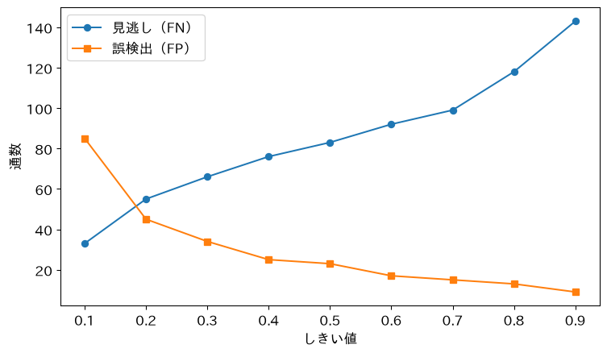

```python
plt.plot(ts, fns, 'o-', label='見逃し（FN）')
plt.plot(ts, fps, 's-', label='誤検出（FP）')
plt.xlabel('しきい値')
plt.ylabel('通数')
plt.legend()
plt.show()
```

#### 1行ずつ読む

- 1行目：横にしきい値、縦に見逃しの線を描く。`'o-'`は丸い点を線でつなぐ
- 2行目：誤検出の線。`'s-'`は四角い点
- 3〜6行目：軸の名前と凡例を付けて、表示する

しきい値0.1では、見逃し33・誤検出85です。0.9では、見逃し143・誤検出9です。2本の線は、逆向きに動きます。

> 重要：しきい値で入れ替わる

> しきい値を下げると見逃しが減って誤検出が増え、上げるとその逆になる。どこで切るかで、同じ式の評価が変わる。

### 全部のしきい値を1枚に：ROC曲線

誤検出率は、普通の通のうち、迷惑と判定してしまった割合です。

$$\text{誤検出率} = \frac{FP}{FP + TN}$$

横に誤検出率、縦に再現率をとり、しきい値を細かく動かして点を打つと、1本の線になります。この線を、ROC曲線と呼びます。左上に近いほど、良い確率です。

`roc_curve(本当, 確率)`は、しきい値を少しずつ下げ、そのたびに誤検出率`fpr`と再現率`tpr`を出して並べる道具です。上の表の9つのしきい値の点も、この線の上に乗ります。

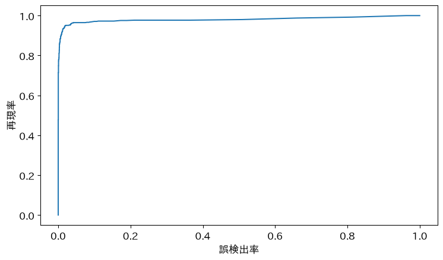

```python
from sklearn.metrics import roc_curve
fpr, tpr, th = roc_curve(df['迷惑'], df['確率'])
plt.plot(fpr, tpr)
plt.xlabel('誤検出率')
plt.ylabel('再現率')
plt.show()
```

#### 1行ずつ読む

- 1行目：ROC曲線の道具`roc_curve`を呼び出す
- 2行目：本当の答えと確率を渡すと、3つが返る。誤検出率の並び`fpr`、再現率の並び`tpr`、しきい値の並び`th`
- 3行目：誤検出率を横、再現率を縦にして、点を線で結ぶ
- 4〜6行目：軸の名前を付けて、図を表示する

#### 中身を見る：3つの並びの長さ

```python
print(len(fpr), len(tpr), len(th))
```

```
276 276 276
```

しきい値を276通り試し、そのたびに誤検出率と再現率を出した

下の図は、横軸を0.2までに広げ、これまでのルール（free・prize・数字5字以上）の点も打ったものです。

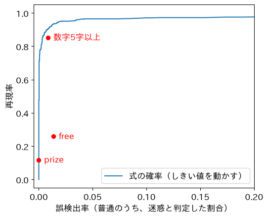

赤い点は、これまでのルールです。どれも、式の線より下（右）にあります。同じ誤検出率なら、式のほうが多くの迷惑を捕まえます。

### お手本：AUCを出す

- 役割：ROC曲線の下の面積（AUC）を出す
- 入力：列「迷惑」と列「確率」
- 出力：AUC

ROC曲線の下の面積を、AUC（area under the curve）と呼びます。1に近いほど、迷惑と普通を確率でよく分けています。でたらめな確率なら0.5です。しきい値を決めなくても出せる、確率の付き方そのものの良さです。`roc_auc_score(本当, 確率)`に、しきい値は渡しません。

```python
from sklearn.metrics import roc_auc_score
print(round(roc_auc_score(df['迷惑'], df['確率']), 3))
```

```
0.981
```

#### 1行ずつ読む

- 1行目：AUCの道具`roc_auc_score`を呼び出す
- 2行目：本当の答えと確率を渡すと、AUCが返る。しきい値は渡さない

#### roc_auc_scoreがしていること

迷惑1通と普通1通を組にして、迷惑のほうが確率の高い組を数えます。たとえば、迷惑の通の確率が0.9、普通の通の確率が0.2なら、その組は迷惑のほうが高い（○）です。迷惑の通が0.1、普通の通が0.2なら×です。迷惑653通と普通4,518通のすべての組でこれを数えた割合が、AUCと同じになります。この式では、0.981の割合の組で、迷惑のほうが確率が高くなっています。

### お手本：LDAでも確率を出す

- 役割：線形判別分析（linear discriminant analysis）で確率を出し、0.5で切って、正解率と混同行列をロジスティック回帰と比べる
- 入力：式の作り方`LinearDiscriminantAnalysis()`
- 出力：正解率と、混同行列

線形判別分析は、英語の頭文字からLDAとも呼びます。式の作り方を、`LogisticRegression()`から`LinearDiscriminantAnalysis()`に替えるだけです。

```python
from sklearn.discriminant_analysis import LinearDiscriminantAnalysis
p = cross_val_predict(LinearDiscriminantAnalysis(), df[cols],
                      df['迷惑'], cv=5, method='predict_proba')
df['判定_lda'] = (p[:, 1] >= 0.5).astype(int)
print(round(accuracy_score(df['迷惑'], df['判定_lda']), 3))
print(confusion_matrix(df['迷惑'], df['判定_lda']))
```

```
0.973
[[4510    8]
 [ 132  521]]
```

#### 1行ずつ読む

- 1行目：LDAの道具`LinearDiscriminantAnalysis`を呼び出す
- 2・3行目：5節の確率のお手本と同じ形。式の作り方だけを替えた
- 4行目：0.5で切って、列「判定_lda」にしまう
- 5・6行目：正解率と混同行列を表示する

正解率は0.973で、ロジスティック回帰（0.98）とほとんど同じです。下のセルで、LDAのAUCも出してみます。

```python
print(round(roc_auc_score(df['迷惑'], p[:, 1]), 3))
```

```
0.981
```

AUCも、ロジスティック回帰と同じ0.981です。1つの数で比べると、2つの式にほとんど差はありません。

ところが、混同行列を並べると、見逃しはロジスティック回帰が83通、LDAが132通です。誤検出は、23通と8通です。LDAは見逃しが多く、誤検出が少ないのです。正解率もAUCも、4つのマスを1つの数にまとめた数で、どちらの誤りで外したかが消えます。

どちらの式が良いかは、誤りの重さで決まります。迷惑フィルターでは、大事な連絡を迷惑フォルダに入れてしまう誤検出のほうが、致命的かもしれません。そうなら、LDAを選ぶこともあります。だから、式どうしを比べるときも、混同行列を並べます（3節と同じです）。

見逃しが増えるのは、LDAの確率が0か1の近くに偏るからです。下のセルで、確率が0か1の近く（0.01未満か0.99より上）にある通の割合を比べます。

```python
print(round(((df['確率'] < 0.01) | (df['確率'] > 0.99)).mean(), 3))
print(round(((p[:, 1] < 0.01) | (p[:, 1] > 0.99)).mean(), 3))
```

```
0.777
0.978
```

LDAは0.978、ロジスティック回帰は0.777の割合の通が、0か1の近くにあります。LDAが悪いのではなく、どこで切るのがよいかが、式ごとに違うのです。違いが出たのは、2つのモデルの仮定（データの出方の考え方）が違うからです。このデータではこうなりましたが、いつもLDAが見逃しを多くする、とは言えません。

### しきい値を下げても、残る見逃し

しきい値を0.1まで下げても、見逃しは33通残りました。迷惑なのに、確率がとても小さい通があるのです。どんなメッセージかを読んでみます。

### お手本：見逃した迷惑を読む

- 役割：迷惑なのに、確率が0.05より小さい通を取り出し、本文を読む
- 入力：列「迷惑」と列「確率」
- 出力：通数と、本文の先頭5通

まず迷惑の通だけを`spam_df`に取り出し、その中から確率が0.05より小さい通を取り出します。

```python
spam_df = df[df['迷惑'] == 1]
low = spam_df[spam_df['確率'] < 0.05]
print(len(low))
low['本文'].head()
```

```
24
```

```
68      Did you hear about the new "Divorce Barbie"? It comes with all of Ken's stuff!
739    Do you realize that in about 40 years, we'll have thousands of old ladies ru...
740                  You have an important customer service announcement from PREMIER.
850    Hello. We need some posh birds and chaps to user trial prods for champneys. ...
862    Reminder: You have not downloaded the content you have already paid for. Got...
Name: 本文, dtype: object
```

#### 1行ずつ読む

- 1行目：迷惑の行だけを取り出し、`spam_df`にしまう
- 2行目：その中から、確率が0.05より小さい行を取り出し、`low`にしまう
- 3行目：`low`の通数を表示する
- 4行目：本文の先頭5通を表示する

### TODO⑤：しきい値を替える（予想 → 実行 → 比べる）

下のセルは、しきい値`t`で判定し、混同行列と2つの割合を表示します。

まず、予想を書いてください。0.3で切ると、見逃し（0.5では83）と誤検出（0.5では23）は、それぞれどう変わるでしょうか。

（ここに予想を書く）

予想を書いたら、セルの`0.5`を`0.3`に替えて実行してください。

```python
# TODO: 0.5 を 0.3 に替えて実行する
t = 0.5
df['判定_x'] = (df['確率'] >= t).astype(int)
print(confusion_matrix(df['迷惑'], df['判定_x']))
print(round(recall_score(df['迷惑'], df['判定_x']), 3))
print(round(precision_score(df['迷惑'], df['判定_x']), 3))
```

```
[[4495   23]
 [  83  570]]
0.873
0.961
```

### やってみよう：予想と比べる

実行した結果を、予想と比べてください。0.3で切ると、見逃しと誤検出はどう変わりましたか。

（ここに答えを書く）

0.3で切ると、見逃しは66通に減り、誤検出は34通に増えました。再現率が上がり、適合率が下がります。式の強みは、しきい値で、見逃しと誤検出の釣り合いを選べることです。

### ここまでで分かったこと

| 段 | 分かったこと |
| --- | --- |
| ルールで見分ける（1・2節） | 「freeを含むなら迷惑」のルールで、正解率0.894 |
| 正解率を疑う（3節） | 何も迷惑と言わなくても0.874。4つのマスで数える |
| 2つの割合（4節） | 数字が5字以上なら迷惑：見逃し96・誤検出39 |
| 確率を出す（5節） | 数字と15語で確率。0.5で切ると見逃し83・誤検出23 |
| しきい値（6節） | 0.3で切ると見逃し66・誤検出34。AUCは0.981 |

5つの段がそろい、今日の問いに答えられます。

### 答え

本文の数字と15語で迷惑である確率を出し、0.5で切ると、迷惑653通のうち570通を捕まえます。そのとき、普通4,518通のうち23通を、誤って迷惑と判定します。しきい値を動かせば、この釣り合いを選べます。

フィルターの評価は、正解率ではなく、混同行列の見逃しと誤検出で行います。何も見分けないルールでも、正解率は0.874になるからです。

まだ言えないこと

- どこで切るべきか：見逃しと誤検出の重さから、しきい値をどう決めるか
- 手がかりの外：数字も決まり文句もない迷惑を、どう捕まえるか
- 確率は信じてよいか：確率0.3と言われた通は、本当に3割が迷惑か

## 目標に答えられたか

- 今日の目標は「本文から、迷惑メッセージをどう見分け、その見分け方をどう評価するか」でした。混同行列の数で答えられますか？
- 2節で、`rule`の中の`if`と`else`は、それぞれどんなときに動きましたか？
- TODO①で、何も迷惑と言わないルールの正解率が高かったのはなぜですか？
- 3節で、`confusion_matrix`の表の、上の行と左の列は、それぞれ何を表しますか？
- 4節で、再現率と適合率は、それぞれ何の少なさを表しますか？
- 5節で、ロジスティック回帰の確率が0〜1をはみ出さないのはなぜですか？
- 6節で、しきい値を下げると、見逃しと誤検出はどう変わりましたか？AUCは何を測りますか？

## 今日の要点

- 今日、持ち帰る1文：迷惑メッセージが少ないと、何も見分けなくても正解率は高くなる。混同行列の4つのマスを数え、見逃しと誤検出を分けて評価する。ロジスティック回帰で迷惑である確率を出すと、どこで切るか（しきい値）で、見逃しと誤検出は入れ替わる
- 重要概念（統計）：混同行列。正解率だけで見ない。4つのマスを数え、見逃しと誤検出を分けて評価する
- 重要概念（Python）：if。条件が成り立つときだけ、字下げしたブロックを実行する。elseの下は、成り立たないときに動く
- 再現率は見逃しの少なさ、適合率は誤検出の少なさ。2つは引っ張り合う
- ロジスティック回帰で確率を出し、しきい値で切る。ROC曲線とAUCで、全部のしきい値を見る

### 分類の広がり

2択を当てる場面は、あちこちにあります。病気の検査は陽性か陰性かを当て、病気の人は少数です。クレジットカードの不正な使い方を見つけるときも、不正はごく一部です。工場の検査で不良品を見つけるときも、不良品はめったに出ません。

どこでも、混同行列で話します。病気の検査では、再現率を感度と呼び、見逃しを減らしたい場面が多くあります。迷惑フィルターでは、大事な連絡を失う誤検出を減らしたい。分野で呼び名は違っても、4つのマスと2つの誤りは同じです。

見つけたいものが少ないほど、正解率は役に立たなくなります。不正がごく一部なら、何もしなくても正解率はほぼ1になります。まず混同行列を作る。今日の流れは、そのまま別のデータに持っていけます。

## 次回へ

今日は、しきい値を動かすと、見逃しと誤検出が入れ替わるのを見ました。では、見逃しと誤検出の重さから、しきい値をどう決めればよいでしょうか。

## 課題（提出）

提出するもの：絵2枚（画像ファイル）。今日の重要概念の、統計とPythonを1枚ずつです。提出フォームから出してください。期限はありません。

コードは書きません。上手な絵である必要はありません。紙に手で描いて写真を撮っても、描画アプリで描いてもかまいません。

### 今日の重要概念（2つ）

- 統計：混同行列。正解率だけで見ない。混同行列の4つのマスを数え、見逃しと誤検出を分けて評価する（3節）
- Python：if。条件が成り立つ（True）ときだけ、字下げしたブロックを実行する。elseの下は、成り立たないときに動く（2・3節）

### 今日の2枚（絵にする）

2つの重要概念を、1枚ずつ絵にしてください。その考えが1枚で伝わる絵です。数式やコードは描かなくてかまいません。半年後の自分が見て、何の話だったか思い出せる絵を目指します。

**詰まったら**

混同行列なら、たとえば「火災報知器の、4つの場合」を描けます。 火事で鳴る、火事なのに鳴らない（見逃し）、料理の煙で鳴る（誤検出）、何もなくて静か、の4つです。3節の2×2の表が手本になります。

**詰まったら**

ifなら、たとえば「駅の自動改札」を描けます。 切符があれば扉が開き、なければ閉まります。2節の「ifの分かれ道」の図のように、1人ずつ、条件で通り道が分かれる様子です。

## 発展（任意）

### すべての単語を列にする

今日は、語を15個だけ選びました。本文に出てくる単語を、すべて列にしたらどうなるでしょうか。`CountVectorizer`は、単語ごとに、含むなら1・含まないなら0の列を作る道具です。

`make_pipeline`は、列を作る道具と式を作る道具をつなぎ、1つの式の作り方にする道具です。これを`cross_val_predict`に渡すと、5回のそれぞれで、式を作る組の本文だけから単語を数えます。

```python
from sklearn.feature_extraction.text import CountVectorizer
from sklearn.pipeline import make_pipeline

vec = CountVectorizer(binary=True).fit(df['本文'])
print(len(vec.vocabulary_), '種類の単語')
```

```
8713 種類の単語
```

#### 1行ずつ読む

- 1・2行目：単語の列を作る道具と、道具をつなぐ道具を呼び出す
- 4行目：全部の本文から、単語の種類を数える（`binary=True`は、含むなら1・含まないなら0）
- 5行目：単語の種類の数を表示する

全部の通で数えると、単語は8,713種類あります。列が、全部の通（5,171通）より多くなります。それでも式が作れるのは、`LogisticRegression`に、第5回のリッジと同じペナルティが、はじめから入っているからです。

```python
pipe = make_pipeline(CountVectorizer(binary=True),
                     LogisticRegression())
p = cross_val_predict(pipe, df['本文'], df['迷惑'], cv=5,
                      method='predict_proba')
print(round(roc_auc_score(df['迷惑'], p[:, 1]), 3))
print(confusion_matrix(df['迷惑'], (p[:, 1] >= 0.5).astype(int)))
```

```
0.988
[[4513    5]
 [  95  558]]
```

#### 1行ずつ読む

- 1・2行目：単語の列を作る道具とロジスティック回帰をつなぎ、`pipe`にしまう
- 3・4行目：`pipe`を式の作り方として渡し、交差検証で確率を出す。手がかりは本文そのもの
- 5行目：AUCを表示する。6行目：0.5で切った判定の混同行列を表示する

AUCは0.988で、今日の16本の手がかり（0.981）より高くなりました。0.5で切ると、見逃し95・誤検出5です。16本の式（83・23）と比べると、見逃しは少し多く、誤検出はずっと少なくなります。

試すなら、`LogisticRegression()`を`LogisticRegression(C=0.1)`に替えてみましょう。`C`はペナルティの弱さで、小さいほどペナルティが強くなります（第5回のαと逆の向き）。